# BW_89_Housing

## BW-89-Housing

1. Create two data frames, one from each of the two Excel files references above, on the "Annual" tab in both files. The columns should be a two-level multi-index. Values labeled (NA) should be turned into NaN. Ignore the header and footer information. The index (rows) should contain the year from the first column.
2. Create a line plot showing total housing starts and completions in the overall United States. Show starts with a dashed blue line, and completed houses with a solid red line. When did the most recent big changes in the housing market take place?
3. Create a line plot showing total housing starts in the US as well as each region. Do the regions all appear to move in sync? Where has most housing construction taken place in the last few decades?
4. Find, for each decade, the number of total housing starts in the overall US. How do housing starts in the most recent years compare with preceding decades? The US population is now about 330m people, and was 203m in 1970; how might this affect the supply and demand for housing?
5. Find, for each decade, the percentage of 1-unit housing starts (of the total) in the overall US. Does the percentage of single-family units appear to be increasing or decreasing over time? Show it in a line plot.
6. In which year did we see the most and least 1-unit homes completed, in the US overall and in each of the tracked regions?
7. Calculate the correlation between the total number of housing starts in each of the four regions of the United States. Which regions, if any, are highly correlated with one another?

```python
import pandas as pd
import numpy as np
import matplotlib.pyplot as plt
```

```python
# Read the CSV file, skipping any unnecessary header and footer information
df1 = (
    pd
    .read_excel('/Users/steven/Jupyter/starts_cust.xlsx',
                header = [4,5], nrows = 65,
                sheet_name = 'Annual',
                na_values = '(NA)',
                index_col = 0)
)

# Display the DataFrame to confirm structure
print(df1)
```

```
Year United States                                          Northeast         \
             Total  1 unit 2 to 4\n units 5 units\n or more     Total 1 unit
1959        1517.0  1234.0            NaN               NaN     268.7    NaN
1960        1252.2   994.7            NaN               NaN     221.4    NaN
1961        1313.0   974.3            NaN               NaN     246.3    NaN
1962        1462.9   991.4            NaN               NaN     263.8    NaN
1963        1603.2  1012.4            NaN               NaN     261.0    NaN
...            ...     ...            ...               ...       ...    ...
2019        1290.0   887.7           13.4             388.9     114.8   57.1
2020        1379.6   990.5           12.3             376.8     111.5   60.2
2021        1601.0  1127.2           11.7             462.1     136.5   67.6
2022        1552.6  1005.2           16.4             531.0     142.1   63.0
2023        1420.0   947.7           13.4             458.8     114.8   60.8

Year Midwest         South          West
       Total 1 unit  Total 1 unit  Total 1 unit
1959   367.4    NaN  511.4    NaN  369.5    NaN
1960   292.0    NaN  429.4    NaN  309.4    NaN
1961   277.7    NaN  472.7    NaN  316.3    NaN
1962   289.6    NaN  531.2    NaN  378.3    NaN
1963   329.2    NaN  586.2    NaN  426.8    NaN
...      ...    ...    ...    ...    ...    ...
2019   169.4  119.8  684.8  496.9  321.0  213.9
2020   191.6  135.6  735.5  553.1  341.0  241.5
2021   215.5  148.2  848.1  643.7  400.8  267.7
2022   205.8  129.7  834.1  581.3  370.6  231.2
2023   184.9  118.0  792.1  564.2  328.2  204.7

[65 rows x 12 columns]
```

```python
# Read the CSV file, skipping any unnecessary header and footer information
df2 = (
    pd
    .read_excel('/Users/steven/Jupyter/comps_cust.xlsx',
                header = [4,5], nrows = 56,
                sheet_name = 'Annual',
                na_values = '(NA)',
                index_col = 0)
)

# Display the DataFrame to confirm structure
print(df2)
```

```
Year United States                                          Northeast         \
             Total  1 unit 2 to 4\n units 5 units\n or more     Total 1 unit
1968        1319.8   858.6           77.4             383.6     198.8    NaN
1969        1399.0   807.5           79.8             512.1     219.8    NaN
1970        1418.4   801.8           85.1             531.5     184.9    NaN
1971        1706.1  1014.0          106.1             586.1     225.8    NaN
1972        2003.9  1160.2          119.2             724.7     281.1    NaN
1973        2100.5  1197.2          123.5             779.8     294.0    NaN
1974        1728.5   940.3           95.3             692.9     231.7    NaN
1975        1317.2   874.8           60.4             381.8     185.8    NaN
1976        1377.2  1034.2           77.1             265.8     170.2    NaN
1977        1657.1  1258.4           94.9             303.7     176.8    NaN
1978        1867.5  1369.0          116.1             382.2     181.9    NaN
1979        1870.8  1301.0          124.9             444.9     188.4  135.2
1980        1501.6   956.7          118.8             426.3     146.0   99.8
```

[output cut: 102 more lines]

```python
(
    df1[[('United States', 'Total')]]
)
```

| Year | United States Total |
| --- | --- |
| 1959 | 1517.0 |
| 1960 | 1252.2 |
| 1961 | 1313.0 |
| 1962 | 1462.9 |
| 1963 | 1603.2 |
| ... | ... |
| 2019 | 1290.0 |
| 2020 | 1379.6 |
| 2021 | 1601.0 |
| 2022 | 1552.6 |
| 2023 | 1420.0 |

65 rows × 1 columns

```python
(
    df2[[('United States', 'Total')]]
)
```

| Year | United States Total |
| --- | --- |
| 1968 | 1319.8 |
| 1969 | 1399.0 |
| 1970 | 1418.4 |
| 1971 | 1706.1 |
| 1972 | 2003.9 |
| 1973 | 2100.5 |
| 1974 | 1728.5 |
| 1975 | 1317.2 |
| 1976 | 1377.2 |
| 1977 | 1657.1 |
| 1978 | 1867.5 |
| 1979 | 1870.8 |
| 1980 | 1501.6 |
| 1981 | 1265.7 |
| 1982 | 1005.5 |
| 1983 | 1390.3 |
| 1984 | 1652.2 |
| 1985 | 1703.3 |
| 1986 | 1756.4 |
| 1987 | 1668.8 |
| 1988 | 1529.8 |
| 1989 | 1422.8 |
| 1990 | 1308.0 |
| 1991 | 1090.8 |
| 1992 | 1157.5 |
| 1993 | 1192.7 |
| 1994 | 1346.9 |
| 1995 | 1312.6 |
| 1996 | 1412.9 |
| 1997 | 1400.5 |
| 1998 | 1474.2 |
| 1999 | 1604.9 |
| 2000 | 1573.7 |
| 2001 | 1570.8 |
| 2002 | 1648.4 |
| 2003 | 1678.7 |
| 2004 | 1841.9 |
| 2005 | 1931.4 |
| 2006 | 1979.4 |
| 2007 | 1502.8 |
| 2008 | 1119.7 |
| 2009 | 794.4 |
| 2010 | 651.7 |
| 2011 | 584.9 |
| 2012 | 649.2 |
| 2013 | 764.4 |
| 2014 | 883.8 |
| 2015 | 968.2 |
| 2016 | 1059.7 |
| 2017 | 1152.9 |
| 2018 | 1184.9 |
| 2019 | 1255.1 |
| 2020 | 1286.9 |
| 2021 | 1341.0 |
| 2022 | 1390.5 |
| 2023 | 1448.8 |

```python
(
    df1[[('United States', 'Total')]]
    .join
    (df2[('United States', 'Total')],
    lsuffix='_starts', rsuffix='_comps')
)
```

|  | United States_starts Total | United States_comps Total |
| --- | --- | --- |
| 1959 | 1517.0 | NaN |
| 1960 | 1252.2 | NaN |
| 1961 | 1313.0 | NaN |
| 1962 | 1462.9 | NaN |
| 1963 | 1603.2 | NaN |
| ... | ... | ... |
| 2019 | 1290.0 | 1255.1 |
| 2020 | 1379.6 | 1286.9 |
| 2021 | 1601.0 | 1341.0 |
| 2022 | 1552.6 | 1390.5 |
| 2023 | 1420.0 | 1448.8 |

65 rows × 2 columns

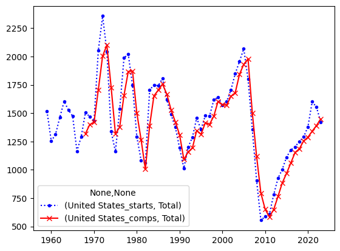

```python
# Plotting
(
    df1[[('United States', 'Total')]]
    .join # Both have to be joined
    (df2[('United States', 'Total')],
    lsuffix='_starts', rsuffix='_comps')
    .plot.line(style='b.: rx-'.split()) # b=blue, (.) = dotted, r=red, x=markers, (-) = dashed
)
```

**Create a line plot showing total housing starts in the US as well as each region. Do the regions all appear to move in sync? Where has most housing construction taken place in the last few decades?**

```python
(
    df1
    .xs('Total',level=1, axis='columns') #and the axis (to indicate we aren't using rows)
)
```

| Year | United States | Northeast | Midwest | South | West |
| --- | --- | --- | --- | --- | --- |
| 1959 | 1517.0 | 268.7 | 367.4 | 511.4 | 369.5 |
| 1960 | 1252.2 | 221.4 | 292.0 | 429.4 | 309.4 |
| 1961 | 1313.0 | 246.3 | 277.7 | 472.7 | 316.3 |
| 1962 | 1462.9 | 263.8 | 289.6 | 531.2 | 378.3 |
| 1963 | 1603.2 | 261.0 | 329.2 | 586.2 | 426.8 |
| ... | ... | ... | ... | ... | ... |
| 2019 | 1290.0 | 114.8 | 169.4 | 684.8 | 321.0 |
| 2020 | 1379.6 | 111.5 | 191.6 | 735.5 | 341.0 |
| 2021 | 1601.0 | 136.5 | 215.5 | 848.1 | 400.8 |
| 2022 | 1552.6 | 142.1 | 205.8 | 834.1 | 370.6 |
| 2023 | 1420.0 | 114.8 | 184.9 | 792.1 | 328.2 |

65 rows × 5 columns

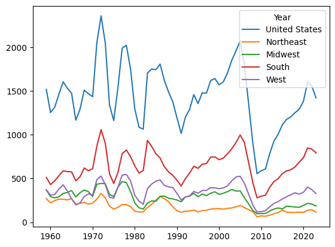

```python
(
    df1
    .xs('Total',level=1, axis='columns') #and the axis (to indicate we aren't using rows)
    .plot.line()
)
```

**Find, for each decade, the number of total housing starts in the overall US. How do housing starts in the most recent years compare with preceding decades? The US population is now about 330m people, and was 203m in 1970; how might this affect the supply and demand for housing?**

```python
# First, we'll need to turn the index back into a regular column. We can do that with reset_index:
# So we take each value in the former index, turn it into a string, add -12-31 to it, and then invoke pd.to_datetime
(
    df1
    .reset_index()
    .assign(date = lambda x: pd.to_datetime(x['index'].astype(str) + '-12-31'))
    .set_index('date') #which we then turn into the index
    [('United States', 'Total')] #because it's a multi-index, we need to use a tuple to specify both of the levels through which we want to drill down:
    .resample('10YE').sum() #.resample(rule, on=None, closed='left', label='left', how=None, axis=0, ...)
)
```

```
date
1959-12-31     1517.0
1969-12-31    14063.8
1979-12-31    17675.8
1989-12-31    14923.0
1999-12-31    13713.6
2009-12-31    15363.5
2019-12-31     9933.0
2029-12-31     5953.2
Freq: 10YE-DEC, Name: (United States, Total), dtype: float64
```

**Find, for each decade, the percentage of 1-unit housing starts (of the total) in the overall US. Does the percentage of single-family units appear to be increasing or decreasing over time? Show it in a line plot.**

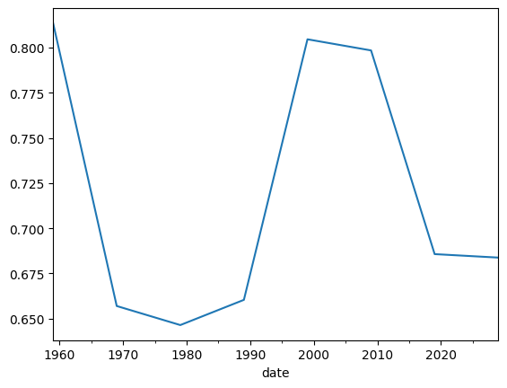

```python
(
    df1
    .reset_index()
    .assign(date = lambda x: pd.to_datetime(x['index'].astype(str) + '-12-31'))
    .set_index('date')
    [[('United States', '1 unit'),('United States', 'Total')]]
    .resample('10YE').sum()
    .assign(pct_1_unit = lambda x:
            x[('United States', '1 unit')]/
            x[('United States', 'Total')])
    ['pct_1_unit']
    .plot.line()

)
```

**In which year did we see the most and least 1-unit homes completed, in the US overall and in each of the tracked regions?**

```python
(
    df2
    .xs('1 unit',level=1, axis='columns') #and the axis (to indicate we aren't using rows)
    .agg(['idxmin','idxmax'])
)
```

| Year | United States | Northeast | Midwest | South | West |
| --- | --- | --- | --- | --- | --- |
| idxmin | 2011 | 2011 | 2011 | 2011 | 2011 |
| idxmax | 2006 | 1987 | 2005 | 2006 | 2005 |

**Calculate the correlation between the total number of housing starts in each of the four regions of the United States. Which regions, if any, are highly correlated with one another?**

```python
# df['Group1'].corr()
# df.unstack(level=0).corr()
# df['Group1']['A'].corr(df['Group2']['B'])

(
    df1
    .xs('Total',level=1, axis='columns') #and the axis (to indicate we aren't using rows)
    .drop('United States', axis=1)
    .corr()
)
```

| Year | Northeast | Midwest | South | West |
| --- | --- | --- | --- | --- |
| Northeast | 1.000000 | 0.695068 | 0.362077 | 0.569715 |
| Midwest | 0.695068 | 1.000000 | 0.500834 | 0.716222 |
| South | 0.362077 | 0.500834 | 1.000000 | 0.827323 |
| West | 0.569715 | 0.716222 | 0.827323 | 1.000000 |